# DataChallenge4_ZYRY

Yanruyu Zhu (yaz4004)

11/5/2020

Link to github repo: https://github.com/ZhuYRY/5018_DataScience.git

```r
# # Load datasets
# park_visits <- readr::read_csv("https://raw.githubusercontent.com/rfordatascience/tidytuesday/master/data/2019/2019-09-17/national_parks.csv")
# state_pop <- readr::read_csv("https://raw.githubusercontent.com/rfordatascience/tidytuesday/master/data/2019/2019-09-17/state_pop.csv")
# gas_price <- readr::read_csv("https://raw.githubusercontent.com/rfordatascience/tidytuesday/master/data/2019/2019-09-17/gas_price.csv")
```

```r
## Load packages
library(readr)
library(dplyr)
library(ggplot2)
library(mosaic)
library(purrr)
```

```r
# Load datasets
gas_price = read.csv("gas_price.csv")
park_visit = read.csv("national_parks.csv")
state_pop = read.csv("state_pop.csv")
```

# Question 1

## Part 1

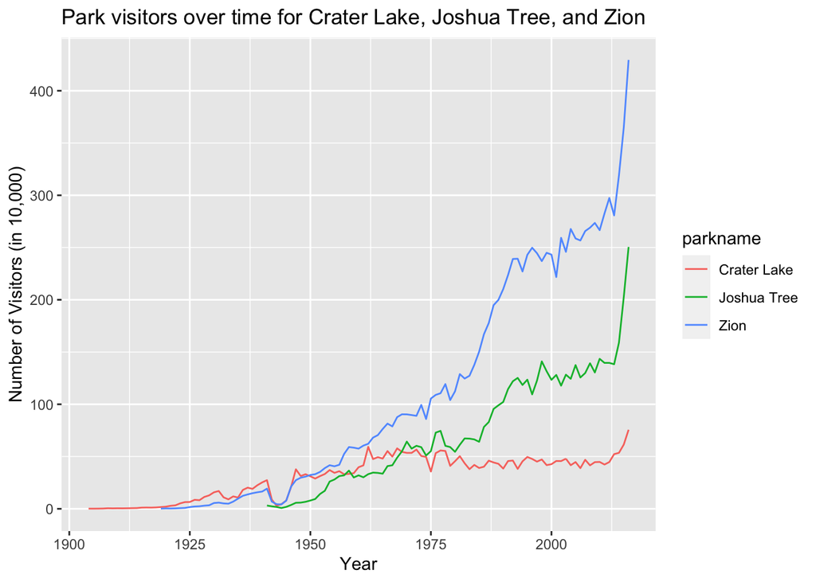

```r
# Clean the dataset
park_1 <- park_visit %>%
  filter(year != "Total") %>%
  ## Remove NAs and change Year into integer
  mutate(year = as.integer(year)) %>%
  ## Select Parks: "Crater Lake", "Joshua Tree", "Zion"
  filter(parkname %in% c("Crater Lake", "Joshua Tree", "Zion")) %>%
  select(year, parkname, state, visitors)
# Make the plot
park_1 %>%
  ggplot(aes(x = year,
             y = visitors/10000,
             col = parkname)) +
  geom_line() +
  labs(x = "Year",
       y = "Number of Visitors (in 10,000)",
       title = "Park visitors over time for Crater Lake, Joshua Tree, and Zion")
```

## Part 2

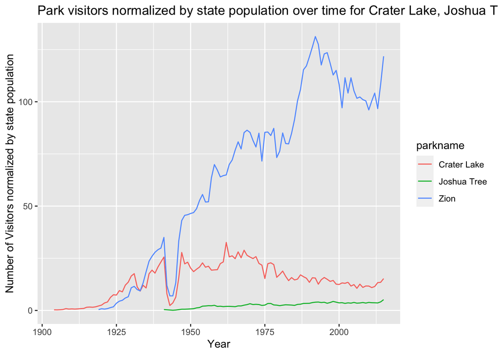

```r
# Clean the dataset
# Use full join to match state population for each park
full_join(park_1, state_pop)%>%
  ## Remove NAs in population
  filter(!is.na(pop)) %>%
  ## Remove NAs in park name
  filter(!is.na(parkname)) %>%
  ## Select states where the three parks
  filter(state %in% c("CA", "OR", "UT")) %>%
  ## Make the plot
  ggplot(aes(x = year,
             y = (visitors/pop)*100,
             col = parkname)) +
  geom_line() +
  labs(x = "Year",
       y = "Number of Visitors normalized by state population",
       title = "Park visitors normalized by state population over time for Crater Lake, Joshua Tree, and Zion")
```

# Question 2

```r
state_sim <- function(park) {
# A funcrion which simulates the number of people who visited the input park in 1942
# and plot the distribution of the simulation and the actual value in the give dataset.
  ## Filter park dataframe for years 1941 and 1942 for a specific state
  yr_41_42 = park_1 %>%
    filter(year %in% c(1941, 1942) & parkname == park) %>%
    arrange(year)
  ## Number of visitors in 1942
  visit_42 = yr_41_42$visitors[2]
  ## Seed
  set.seed(1942)
  ## 1000 times simulation with equal probability
  ## Format: dataframe
  simulation = replicate(1000, sum(rbinom(sum(yr_41_42$visitors),1,.5)))
  simulation = data.frame(simulation)

  ## Make the plot of the distribution of the simulation and the actual value
  simulation %>%
    ggplot(aes(x = simulation)) +
    geom_histogram(bins = 50) +
    ### The line of the actual value and the mark
    geom_vline(xintercept = visit_42,
               col = 'red', size = 2) +
    annotate("text",
             x = visit_42, y = 45,
             label = 'observed',
             hjust = 'left') +
    ### Title, xy axis
    xlab("Number of simulated visitors in 1942 (if equal probability), in 1,000") +
    ylab("Count") +
    ggtitle(paste("Simulation of Number of people who visited",park,"in 1942"))

}
```

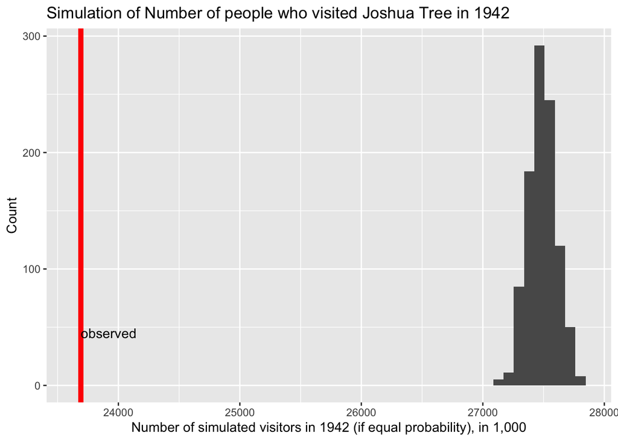

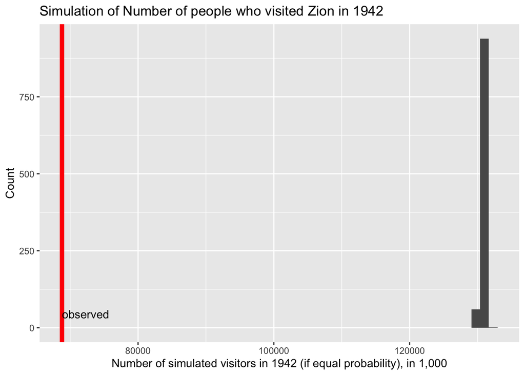

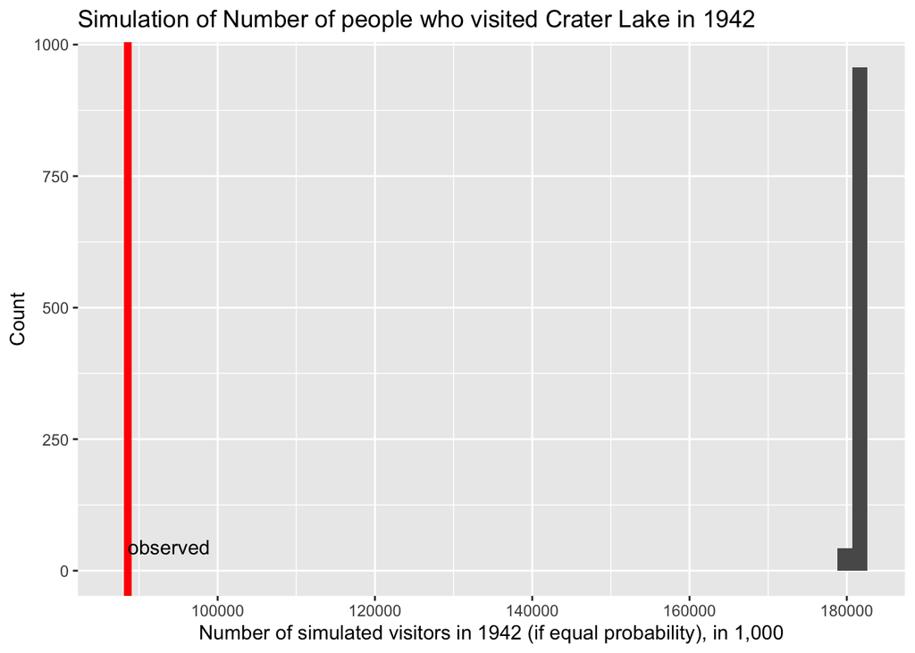

```r
map(c("Joshua Tree",
      "Zion",
      "Crater Lake"),
    state_sim)
```

# Question 3

## Description of the graphs:

### Q1.

The graph of “Park visitors over time for Crater Lake, Joshua Tree, and Zion” over the years shows how number of people who visited Joshua Tree, Zion and Crater Lake National Parks changed over time. It is obvious that in general, the number of visitors to all three parks is overall increasing. And Zion has the most visitors, Joshua Tree the second, and Crater Lake the least.  
The graph of “Park visitors normalized by state population over time for Crater Lake, Joshua Tree, and Zion” shows the number of visitors normalized by the state’s population during that year. The number of visitors to Crater Lake increases from around 1920 to around 1965, and decreases since then. The number of visitors to Zion is overall increasing a lot, while the number of visitors to Joshua Tree is increasing slightly. It is noticeable that between 1940-1945 there is a huge drop then a even larger increase in the number of visitors to both Zion and Crater Lake. Such situation might be explained by the population loss due to World War II and the after war baby boom.

### Q2.

The graphs in Question 2 shows a simulation for the three parks (Crater Lake, Joshua Tree, and Zion) where there is an equal chance of visiting each of the parks in both 1941 and 1942.  
For all three parks, the number of people who actually visited the park in 1942 is much less than our simulations. For Joshua Tree, the simulated visitors spread out and follow approximately normal distribution, with a center around 27500, while the actual value is around 23750.  
For Zion, the simulated visitors are less spread out with a center at around 131000 people while the actual value is around 68000.  
For Crater Lake, the simulated visitors are centered at around 180000, while actual observed value of 88000 people. Note that there is a larger difference between the center of the simulation and the actual value in the dataset.